# When Monty Hall runs into Bayes !

Scroll through this storytelling journey to quickly understand the Monty Hall problem and make link with Bayes’s theorem.

Imagine you’re playing a game where you have to choose one of three doors.

Behind one door is a winning card, and behind the other two are goats.

After you make your choice

the host—who knows what’s behind each door—opens one of the two remaining doors to reveal a goat.

Then, they ask if you’d like to switch your original choice.

Would you stick with your original choice, or switch to the other door?

If you believe that your choice doesn’t affect the odds of winning the car, then the rest of the explanation will be valuable to you.

At the beginning of the game, when you do your first choice, the probability that you choose the correct door with the car is 1/3.

It is means as well that the probability that you choose a door with a goats is 2/3.

After your first choice, the host will open one of the two remaining doors behind which we have a goat.

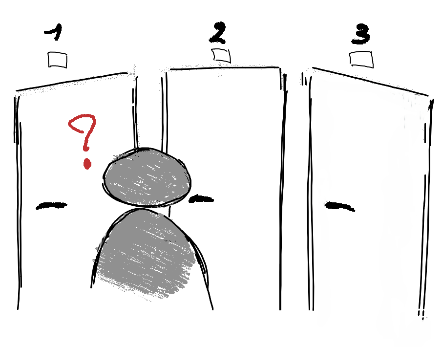

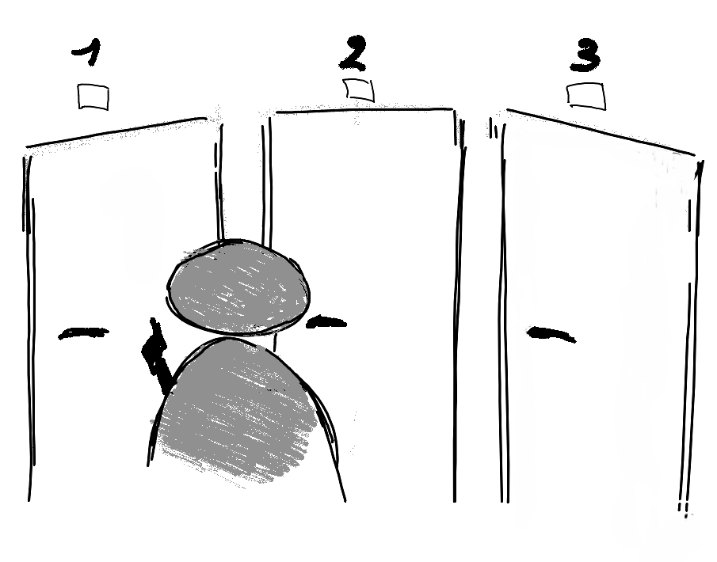

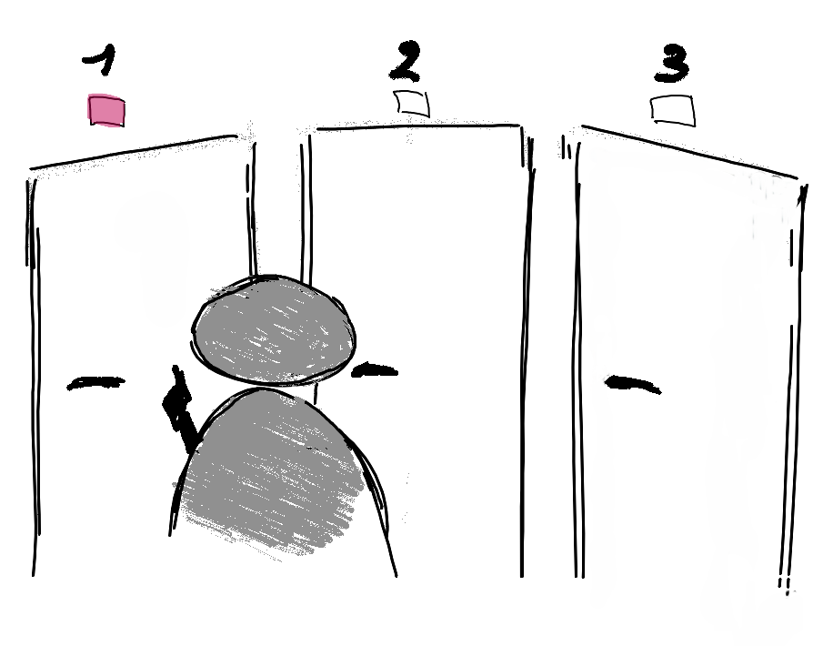

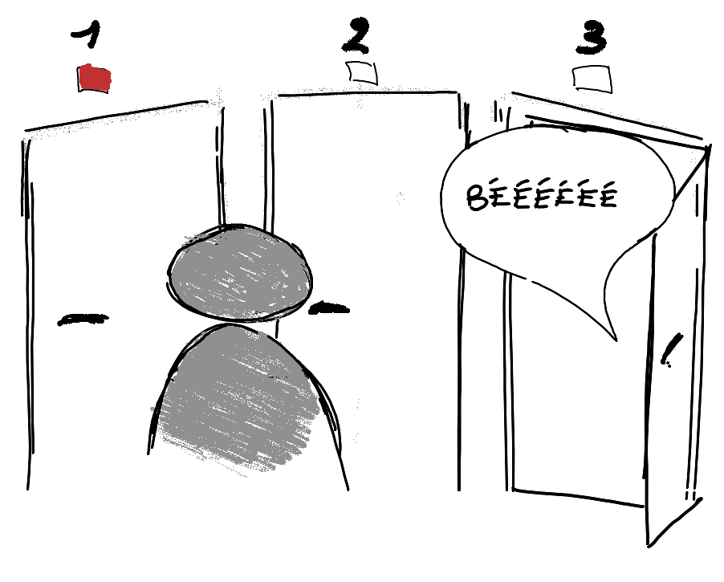

[figure not shown]